# S&DS 627: Statistical Computing - Homework

Sahil Singh

2023-02-24

## Scrape https://www.azlyrics.com/b/beatles.html to find top 10 words

Load scraped RDS file (to avoid scraping again and again)

```r
lyrics <- readRDS("lyrics")
```

### Code for scraping (do not run)

```r
##########################
#  ---DONT RUN AGAIN---  #
##########################

# # Main page
# x <- scan("https://www.azlyrics.com/b/beatles.html", what = "", sep = "\n")
#
# ## Getting all urls from the main page for each song
# urls <- list()
# for (i in 1:length(x)) {
#   # extract URLs using regular expressions
#   urls[[i]] <- ifelse(grepl('href="/lyrics/beatles', x[i]),
#                       paste0("https://www.azlyrics.com", ## Completing link
#                              gsub('.*href="(/lyrics/beatles.*?)".*',
#                                   '\\1',
#                                   x[i])),
#                       NA)
# }
# urls <- urls[is.na(urls) == F] # Dropping NAs
#
# ## Getting lyrics from all the urls
#
# lyrics <- list()
#
# # Define the time interval in seconds for loop delay
# time_interval <- 330 # 5.5 minutes
#
# # Running loop at specified time intervals as IP Address updates in background
# for (j in 1:48) {
#   # Scraping each link to extract the lyrics
#   for (i in (length(lyrics)+1):(length(lyrics)+9)) {
#     y <- scan(urls[[i]], what = "", sep = "\n")
#     a <- grep("<!-- Usage of azlyrics.com content by any third-party lyrics provider is prohibited by our licensing agreement. Sorry about that. -->", y)
#     b <- grep("</div>", y[a+1:length(y)])[1] + a
#     slyrics <- y[(a+1):(b-1)]
#     lyrics[[i]] <- lapply(slyrics, function(x) gsub("<br>", "", x))
#   }
#   # Pause the execution of the loop for 5.5 minutes to update IP Address
#   Sys.sleep(time_interval)
# }
#
# # saving file for future use
# saveRDS(lyrics, file="lyrics")

##########################
# ^^^ DONT RUN AGAIN ^^^ #
##########################
```

### Finding top ten words

```r
mylrc <- lyrics

mylrc <- lapply(mylrc, function(x) {
  # Convert to lowercase
  x <- tolower(x)
  # Remove special characters
  x <- gsub("[^[:alpha:][:space:]]", "", x)
  # Split into words
  x <- unlist(strsplit(x, "\\s+"))
  # Return modified string
  return(x)
})

# Unlist the output
mylrc <- unlist(mylrc)

# Remove empty strings
mylrc <- mylrc[mylrc != ""]

# Scan stop words from "https://gist.githubusercontent.com/sebleier/554280/raw/7e0e4a1ce04c2bb7bd41089c9821dbcf6d0c786c/NLTK's%2520list%2520of%2520english%2520stopwords"
stopwords <- scan("https://gist.githubusercontent.com/sebleier/554280/raw/7e0e4a1ce04c2bb7bd41089c9821dbcf6d0c786c/NLTK's%2520list%2520of%2520english%2520stopwords",
          what = "",
          sep = "\n")

# Remove stop words
mylrc <- mylrc[!(mylrc %in% stopwords)]

# Count the number of occurrences of each word
word_counts <- table(mylrc)

# Sort the word counts in descending order
word_counts <- sort(word_counts, decreasing = TRUE)

# Displaying top ten words
word_counts[1:10]
```

```
## mylrc
## love know   im   oh dont yeah baby  got well  get
## 1057  744  673  665  621  604  481  418  392  339
```

### Visualizing the outcome

```r
# Converting to dataframe for ease in visualizations
topwords <- data.frame("words" = as.character(names(word_counts)),
                 "counts" = as.numeric(word_counts))
```

#### Bar plot

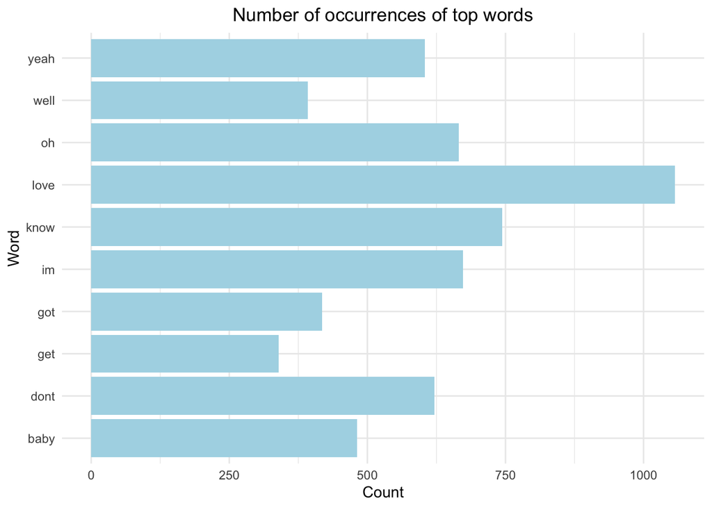

```r
# Horizontal bar plot
ggplot(topwords[1:10,], aes(x = counts, y = words)) +
  geom_bar(stat = "identity", fill = "lightblue") +
  labs(x = "Count", y = "Word", title = "Number of occurrences of top words") +
  theme_minimal() +
  theme(plot.title = element_text(hjust = 0.5))
```

#### Pie Chart

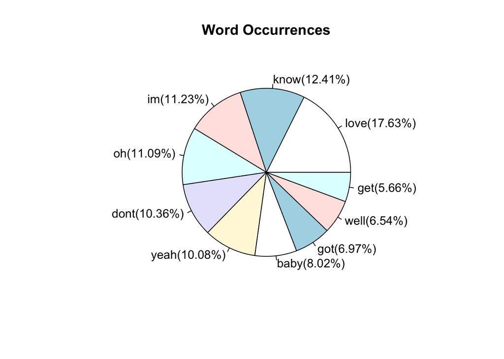

```r
percentages <- round(topwords$counts[1:10]/sum(topwords$counts[1:10])*100, 2)
labels <- paste(topwords$words[1:10], "(", percentages, "%)", sep = "")

pie(topwords$counts[1:10], labels = labels, main = "Word Occurrences")
```

#### Word cloud

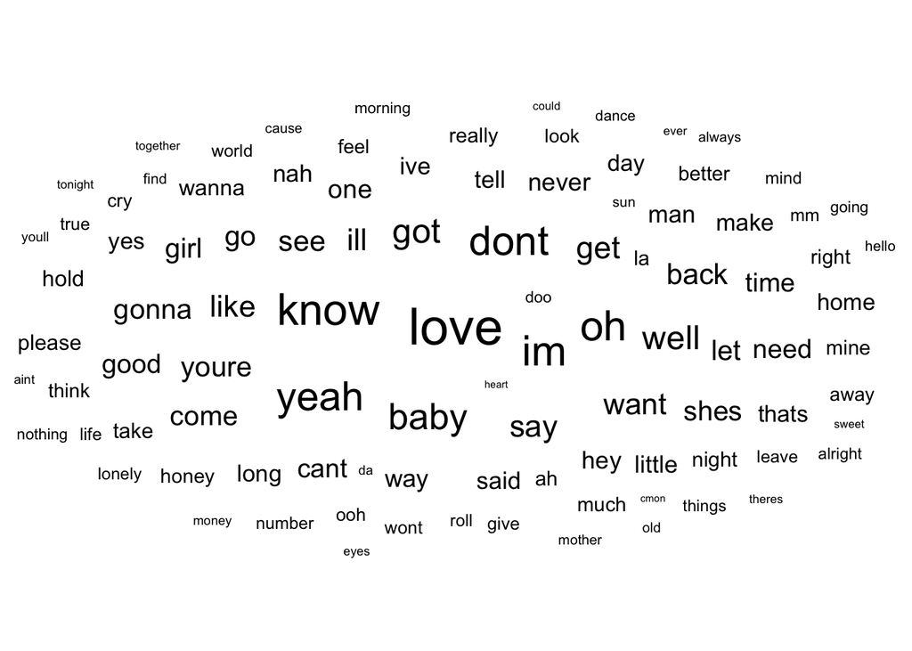

```r
# Create word cloud using ggplot2
ggplot(topwords[1:100,], aes(label = words, size = counts)) +
  geom_text_wordcloud() +
  scale_size(range = c(2, 10)) +
  theme_minimal()
```

#### New Beatles song using ChatGPT

##### Never Gonna Let You Go

Verse 1:  
I know you love me, oh can’t you see  
I’m the one for you, baby just believe  
I’m not like the others, don’t you know  
I’ll never let you go, I’ll never let you go  
Chorus:  
Yeah, yeah, yeah, I got you now  
Oh, oh, oh, don’t you ever doubt  
My love for you is strong, well, you know  
I’m never gonna leave, I’m never gonna go  
Verse 2:  
Imperfect as I am, you accept me for me  
You know all my flaws, yet you still believe  
In our love, in our forever  
I’m so grateful we’re together  
Chorus:  
Yeah, yeah, yeah, I got you now  
Oh, oh, oh, don’t you ever doubt  
My love for you is strong, well, you know  
I’m never gonna leave, I’m never gonna go  
Bridge:  
Sometimes things may get rough  
But with you by my side, I’m tough  
I can get through anything, don’t you see  
As long as you’re here with me  
Chorus:  
Yeah, yeah, yeah, I got you now  
Oh, oh, oh, don’t you ever doubt  
My love for you is strong, well, you know  
I’m never gonna leave, I’m never gonna go  
Outro:  
I love you, baby, with all my heart  
And I promise, we’ll never be apart  
So just hold on tight, and never let go  
’Cause together, we’ll weather any storm, well, you know.